# Snowshoe Hare Report

Ali Martin

11/3/2021

## 1.Overview

This report provides an exploratory overview of differences in weights for male and female juvenile snowshoe hares, as well as the relationship between weights and hind foot length in juvenile hares observed at Bonanza Creek Experimental Forest 1999 to 2012 (Kielland, K., F.S. Chapin, R.W. Ruess, and Bonanza Creek LTER. 2017).

## 2. Data and Analyses

Hare weights and other size measurements were collected and made available by Senior Investigator Knut Kielland and colleagues at the Bonanza Creek Experimental Forest (Long Term Ecological Research Site) in Fairbanks, Alaska (See Map from Kielland, et.al). The data contains observations for 3197 snowshoe hares collected from 1999 to 2012. Following exploratory data visualization, weights between male and female hares are by two-sample t-tests using a significance level ($\alpha$) of 0.05 throughout. Differences between groups are described by Cohen’s *d* effect size. The relationship between weight and hind foot length is explored by simple linear regression. All analyses are in R version 4.1.1 using RStudio version 1.3.1056.

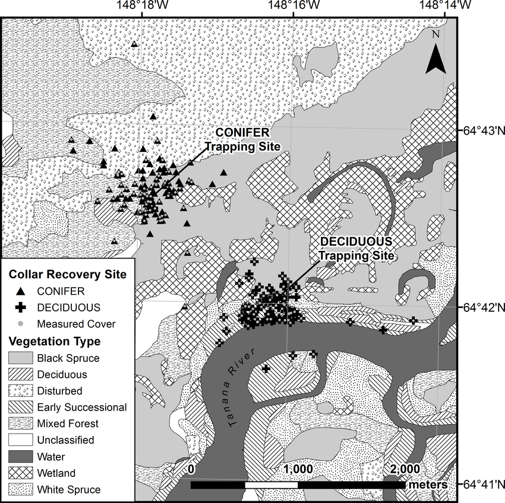

**Figure 1.** Map of Bonanza Creek Trapping Locations (Kielland, et.al, 2017)

## 3. Juvenile Hare Initial Investigation

### Annual juvenile hare trap counts

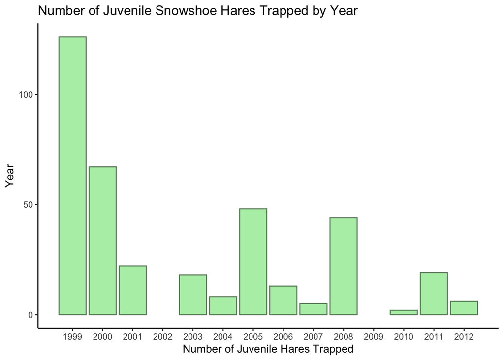

**Figure 2:** The figure above shows the number of juvenile snowshoe hares trapped according to each year

The maximum number of hare trappings occurred in the year 1999 at a count of 126 trappings that year. The minimum counts of juvenile hare trappings occurred in 2010, at a number of only 2 trappings. Overall, the mean number of hares trapped is 31.5 and the median number of hares trapped is 18.5. In the years 2002 and 2009, there does not seem to be any data that includes number of juvenile hares that were trapped. The graph also shows that between 1999 and 2012, the number of hares being trapped has been decreasing. In order to standardize the juvenile hare population for the future, perhaps there will be a standard number of traps that are set out each day.